```r
options(scipen = 999)
```

# Dimensionality reduction techniques

## Loading and inspecting the data

This weeks data deals with human development indicators and the data sets originate from the United Nations Development Programme. You can find more information about the data on their web page: http://hdr.undp.org/en/content/human-development-index-hdi.

Let’s do a couple of visualisations of the data.

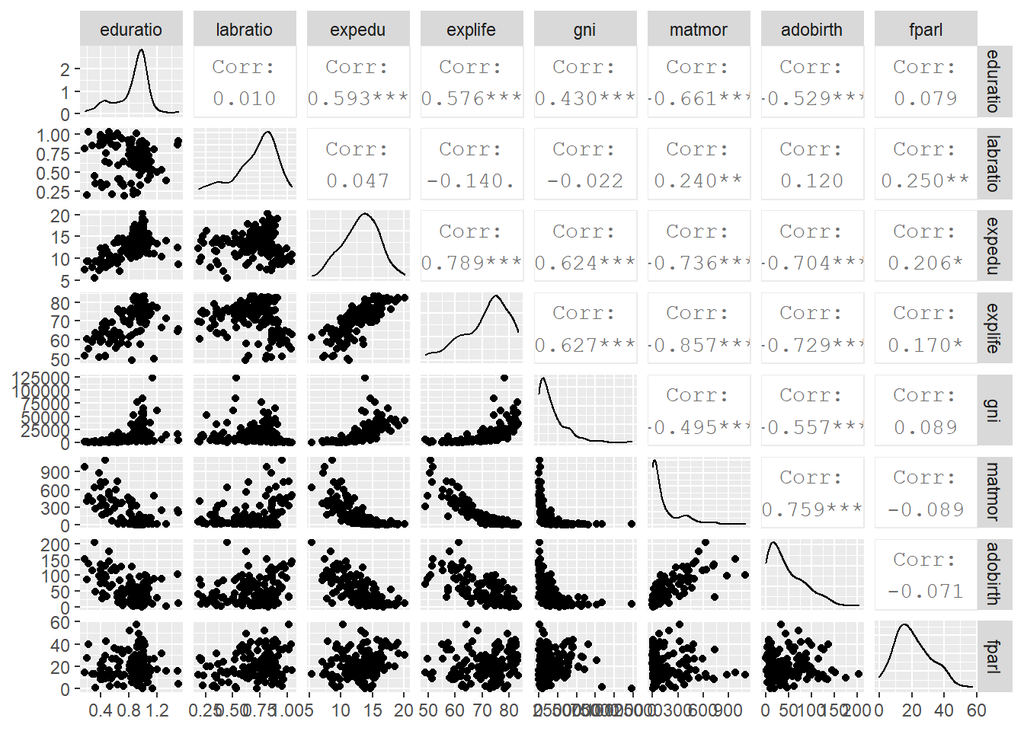

```r
human <- read.csv("data/human.csv", row.names = 1)
ggpairs(human)
```

The above matrix shows scatterplots, distributions, and correlations between variables. The distributions of some variables are quite skewed. Most notably, the gross national income per capita (gni) and maternal mortality (matmor) have mostly low value observations and few high value observations.

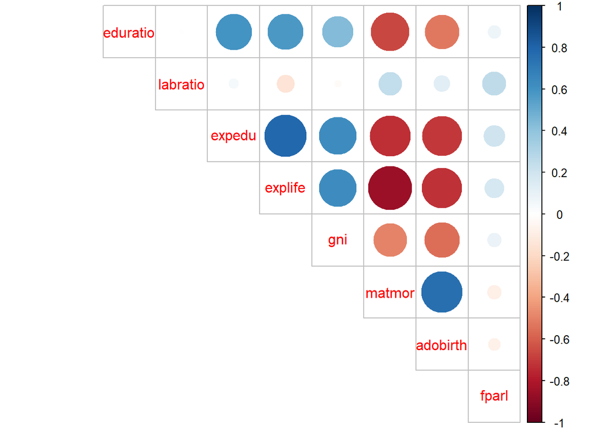

```r
corrplot(cor(human), method="circle", type = "upper", tl.pos = "d")
```

This correlation plot shows all correlations in a glance. The highest negative correlation is between maternal mortality and life expectancy at birth, while the highest positive correlation is between expected years of schooling and life expectancy at birth.

Here are also summaries of the variables:

```r
summary(human)
```

```
##     eduratio         labratio          expedu         explife
##  Min.   :0.1717   Min.   :0.1857   Min.   : 5.40   Min.   :49.00
##  1st Qu.:0.7264   1st Qu.:0.5984   1st Qu.:11.25   1st Qu.:66.30
##  Median :0.9375   Median :0.7535   Median :13.50   Median :74.20
##  Mean   :0.8529   Mean   :0.7074   Mean   :13.18   Mean   :71.65
##  3rd Qu.:0.9968   3rd Qu.:0.8535   3rd Qu.:15.20   3rd Qu.:77.25
##  Max.   :1.4967   Max.   :1.0380   Max.   :20.20   Max.   :83.50
##       gni             matmor          adobirth          fparl
##  Min.   :   581   Min.   :   1.0   Min.   :  0.60   Min.   : 0.00
##  1st Qu.:  4198   1st Qu.:  11.5   1st Qu.: 12.65   1st Qu.:12.40
##  Median : 12040   Median :  49.0   Median : 33.60   Median :19.30
##  Mean   : 17628   Mean   : 149.1   Mean   : 47.16   Mean   :20.91
##  3rd Qu.: 24512   3rd Qu.: 190.0   3rd Qu.: 71.95   3rd Qu.:27.95
##  Max.   :123124   Max.   :1100.0   Max.   :204.80   Max.   :57.50
```

## Principal component analysis

Next, I’ll perform the principal component analysis on the unstandardised data.

```r
pca_human <- prcomp(human)
summary(pca_human)
```

```
## Importance of components:
##                               PC1      PC2   PC3   PC4   PC5   PC6    PC7
## Standard deviation     18544.1639 185.5219 25.19 11.45 3.766 1.566 0.1912
## Proportion of Variance     0.9999   0.0001  0.00  0.00 0.000 0.000 0.0000
## Cumulative Proportion      0.9999   1.0000  1.00  1.00 1.000 1.000 1.0000
##                           PC8
## Standard deviation     0.1591
## Proportion of Variance 0.0000
## Cumulative Proportion  1.0000
```

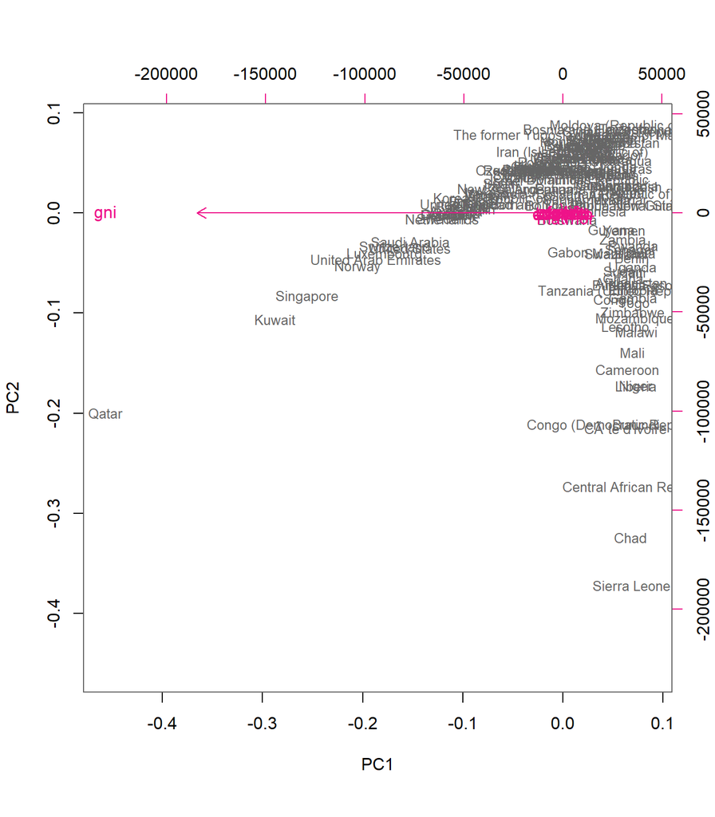

Figure 1. A biplot displaying variation captured by the first two principal components. The first component is mostly determined by gross national income per capita (gni) and it explains almost all of the variability

```r
biplot(pca_human, choices = 1:2, cex = c(0.8, 1), col = c("grey40", "deeppink2"))
```

The summary of the importance of components shows that the first component explains almost all of the variation. From the plot above (Figure 1) we can see that this component is mostly determined by GNI variable. This can be explained by that GNI has much larger range of values than the other variables, as seen in the summary. Therefore, it also has the largest variance. To identify the importance of different variables, we need to standardise the data.

```r
human_std <- scale(human)
summary(human_std)
```

```
##     eduratio          labratio           expedu           explife
##  Min.   :-2.8189   Min.   :-2.6247   Min.   :-2.7378   Min.   :-2.7188
##  1st Qu.:-0.5233   1st Qu.:-0.5484   1st Qu.:-0.6782   1st Qu.:-0.6425
##  Median : 0.3503   Median : 0.2316   Median : 0.1140   Median : 0.3056
##  Mean   : 0.0000   Mean   : 0.0000   Mean   : 0.0000   Mean   : 0.0000
##  3rd Qu.: 0.5958   3rd Qu.: 0.7350   3rd Qu.: 0.7126   3rd Qu.: 0.6717
##  Max.   : 2.6646   Max.   : 1.6632   Max.   : 2.4730   Max.   : 1.4218
##       gni              matmor           adobirth           fparl
##  Min.   :-0.9193   Min.   :-0.6992   Min.   :-1.1325   Min.   :-1.8203
##  1st Qu.:-0.7243   1st Qu.:-0.6496   1st Qu.:-0.8394   1st Qu.:-0.7409
##  Median :-0.3013   Median :-0.4726   Median :-0.3298   Median :-0.1403
##  Mean   : 0.0000   Mean   : 0.0000   Mean   : 0.0000   Mean   : 0.0000
##  3rd Qu.: 0.3712   3rd Qu.: 0.1932   3rd Qu.: 0.6030   3rd Qu.: 0.6127
##  Max.   : 5.6890   Max.   : 4.4899   Max.   : 3.8344   Max.   : 3.1850
```

Now we can see from the summary, that the data is standardised. All means are now 0.

```r
pca_human_std <- prcomp(human_std)
summary(pca_human_std)
```

```
## Importance of components:
##                           PC1    PC2     PC3     PC4     PC5     PC6     PC7
## Standard deviation     2.0708 1.1397 0.87505 0.77886 0.66196 0.53631 0.45900
## Proportion of Variance 0.5361 0.1624 0.09571 0.07583 0.05477 0.03595 0.02634
## Cumulative Proportion  0.5361 0.6984 0.79413 0.86996 0.92473 0.96069 0.98702
##                            PC8
## Standard deviation     0.32224
## Proportion of Variance 0.01298
## Cumulative Proportion  1.00000
```

Now the summary of the importance of components shows that the first component explains about 53.6% of the variation and the second component explains about 16.2%.

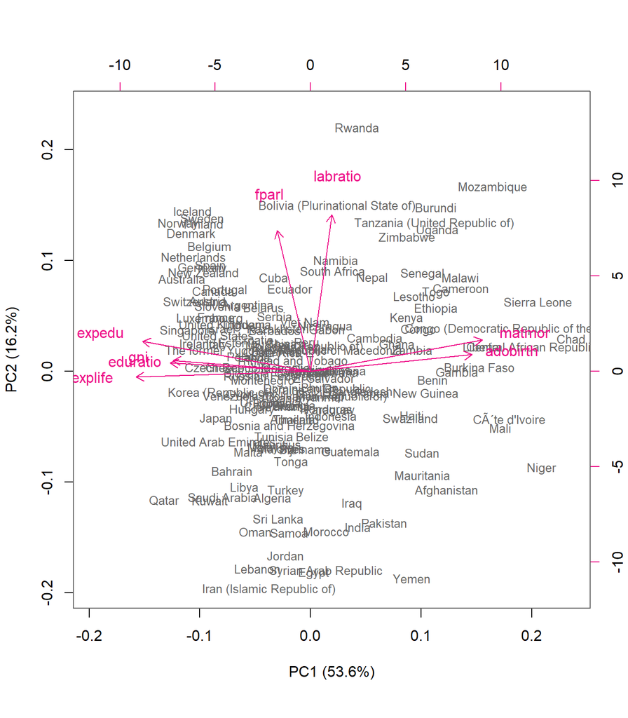

Figure 2. A biplot displaying variation captured by the first two principal components of the principal component analysis performed on the standardised data. The first component is determined by life expectancy, ratio of females to males with at least secondary education, gross national income per capita (gni), expected years of schooling, maternal mortality, and adolescent birth rate. The second component is determined by percetange of female representatives in parliament and ratio of females to males in the labour force.

```r
s <- summary(pca_human_std)
pca_pr <- round(100*s$importance[2, ], digits = 1)
pc_lab <- paste0(names(pca_pr), " (", pca_pr, "%)")
biplot(pca_human_std, choices = 1:2, cex = c(0.8, 1), col = c("grey40", "deeppink2"), xlab = pc_lab[1], ylab = pc_lab[2])
```

Here we can see how variables correlate with principal components and with each other (Figure 2). The angles between the arrows can be interpreted as correlations between the variables and the angles between arrows and principal component axes as correlations between them. The first principal component is defined by two sets of variables that correlate positively with each other but that are negatively correlated with the other set. One set includes life expectancy, ratio of females to males with at least secondary education, gross national income per capita (gni), and expected years of schooling. The other set includes maternal mortality and adolescent birth rate. The first principal component seems to catch variation mostly related to human development factors. The second principal component is defined by percetange of female representatives in parliament and ratio of females to males in the labour force, which correlate positively with each other. The second principal component seems to catch variation related to gender equality factors.

## Multiple correspondence analysis

Multiple correspondence analysis can be used to analyse qualitative data, such as categorical variables. I’ll run multiple correspondence analysis using tea data set from FactoMineR package.

```r
library(FactoMineR)
data(tea)
str(tea)
```

```
## 'data.frame':    300 obs. of  36 variables:
##  $ breakfast       : Factor w/ 2 levels "breakfast","Not.breakfast": 1 1 2 2 1 2 1 2 1 1 ...
##  $ tea.time        : Factor w/ 2 levels "Not.tea time",..: 1 1 2 1 1 1 2 2 2 1 ...
##  $ evening         : Factor w/ 2 levels "evening","Not.evening": 2 2 1 2 1 2 2 1 2 1 ...
##  $ lunch           : Factor w/ 2 levels "lunch","Not.lunch": 2 2 2 2 2 2 2 2 2 2 ...
##  $ dinner          : Factor w/ 2 levels "dinner","Not.dinner": 2 2 1 1 2 1 2 2 2 2 ...
##  $ always          : Factor w/ 2 levels "always","Not.always": 2 2 2 2 1 2 2 2 2 2 ...
##  $ home            : Factor w/ 2 levels "home","Not.home": 1 1 1 1 1 1 1 1 1 1 ...
##  $ work            : Factor w/ 2 levels "Not.work","work": 1 1 2 1 1 1 1 1 1 1 ...
##  $ tearoom         : Factor w/ 2 levels "Not.tearoom",..: 1 1 1 1 1 1 1 1 1 2 ...
##  $ friends         : Factor w/ 2 levels "friends","Not.friends": 2 2 1 2 2 2 1 2 2 2 ...
##  $ resto           : Factor w/ 2 levels "Not.resto","resto": 1 1 2 1 1 1 1 1 1 1 ...
##  $ pub             : Factor w/ 2 levels "Not.pub","pub": 1 1 1 1 1 1 1 1 1 1 ...
##  $ Tea             : Factor w/ 3 levels "black","Earl Grey",..: 1 1 2 2 2 2 2 1 2 1 ...
##  $ How             : Factor w/ 4 levels "alone","lemon",..: 1 3 1 1 1 1 1 3 3 1 ...
```

[output cut: 22 more lines]

```r
dim(tea)
```

```
## [1] 300  36
```

The data contains 300 observations of 36 variables. Other variable types are categorical, but age is an integer. Therefore, I’ll drop age from the analysis.

```r
tea <- tea %>% dplyr::select(-age)
```

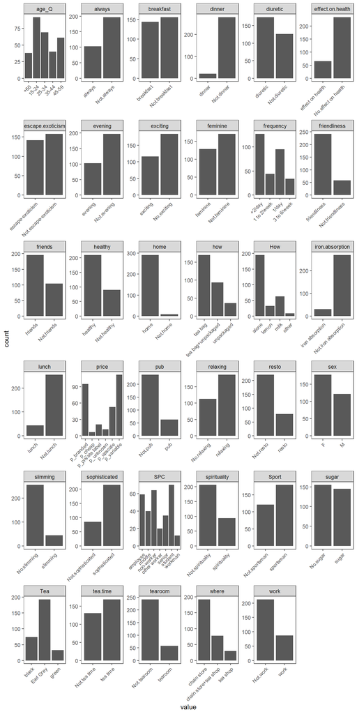

```r
gather(tea) %>% ggplot(aes(value)) +
        geom_bar() +
        theme_bw() +
        facet_wrap("key", scales = "free") +
        theme(
        panel.grid.major=element_blank(),
        panel.grid.minor=element_blank(),
        axis.text.x = element_text(angle = 45, hjust = 1, size = 8))
```

```r
mca <- MCA(tea, graph = FALSE)
summary(mca)
```

```
##
## Call:
## MCA(X = tea, graph = FALSE)
##
##
## Eigenvalues
##                        Dim.1   Dim.2   Dim.3   Dim.4   Dim.5   Dim.6   Dim.7
## Variance               0.090   0.082   0.070   0.063   0.056   0.053   0.050
## % of var.              5.838   5.292   4.551   4.057   3.616   3.465   3.272
## Cumulative % of var.   5.838  11.130  15.681  19.738  23.354  26.819  30.091
##                        Dim.8   Dim.9  Dim.10  Dim.11  Dim.12  Dim.13  Dim.14
## Variance               0.048   0.047   0.044   0.041   0.040   0.039   0.037
## % of var.              3.090   3.053   2.834   2.643   2.623   2.531   2.388
## Cumulative % of var.  33.181  36.234  39.068  41.711  44.334  46.865  49.252
##                       Dim.15  Dim.16  Dim.17  Dim.18  Dim.19  Dim.20  Dim.21
## Variance               0.036   0.035   0.034   0.032   0.031   0.031   0.030
## % of var.              2.302   2.275   2.172   2.085   2.013   2.011   1.915
## Cumulative % of var.  51.554  53.829  56.000  58.086  60.099  62.110  64.025
##                       Dim.22  Dim.23  Dim.24  Dim.25  Dim.26  Dim.27  Dim.28
## Variance               0.028   0.027   0.026   0.025   0.025   0.024   0.024
## % of var.              1.847   1.740   1.686   1.638   1.609   1.571   1.524
## Cumulative % of var.  65.872  67.611  69.297  70.935  72.544  74.115  75.639
##                       Dim.29  Dim.30  Dim.31  Dim.32  Dim.33  Dim.34  Dim.35
## Variance               0.023   0.022   0.021   0.020   0.020   0.019   0.019
## % of var.              1.459   1.425   1.378   1.322   1.281   1.241   1.222
## Cumulative % of var.  77.099  78.523  79.901  81.223  82.504  83.745  84.967
##                       Dim.36  Dim.37  Dim.38  Dim.39  Dim.40  Dim.41  Dim.42
## Variance               0.018   0.017   0.017   0.016   0.015   0.015   0.014
## % of var.              1.152   1.092   1.072   1.019   0.993   0.950   0.924
## Cumulative % of var.  86.119  87.211  88.283  89.301  90.294  91.244  92.169
##                       Dim.43  Dim.44  Dim.45  Dim.46  Dim.47  Dim.48  Dim.49
## Variance               0.014   0.013   0.012   0.011   0.011   0.010   0.010
## % of var.              0.891   0.833   0.792   0.729   0.716   0.666   0.660
## Cumulative % of var.  93.060  93.893  94.684  95.414  96.130  96.796  97.456
##                       Dim.50  Dim.51  Dim.52  Dim.53  Dim.54
## Variance               0.009   0.009   0.008   0.007   0.006
## % of var.              0.605   0.584   0.519   0.447   0.390
## Cumulative % of var.  98.060  98.644  99.163  99.610 100.000
##
## Individuals (the 10 first)
```

[output cut: 44 more lines]

```
## dinner         0.796  1.805  0.048  3.777 |
## Not.dinner    -0.060  0.136  0.048 -3.777 |
##
## Categorical variables (eta2)
##                 Dim.1 Dim.2 Dim.3
## breakfast     | 0.031 0.000 0.011 |
## tea.time      | 0.240 0.000 0.003 |
## evening       | 0.040 0.087 0.062 |
## lunch         | 0.062 0.029 0.010 |
## dinner        | 0.092 0.000 0.048 |
## always        | 0.056 0.035 0.007 |
## home          | 0.016 0.002 0.030 |
## work          | 0.075 0.020 0.022 |
## tearoom       | 0.321 0.019 0.031 |
## friends       | 0.186 0.061 0.030 |
```

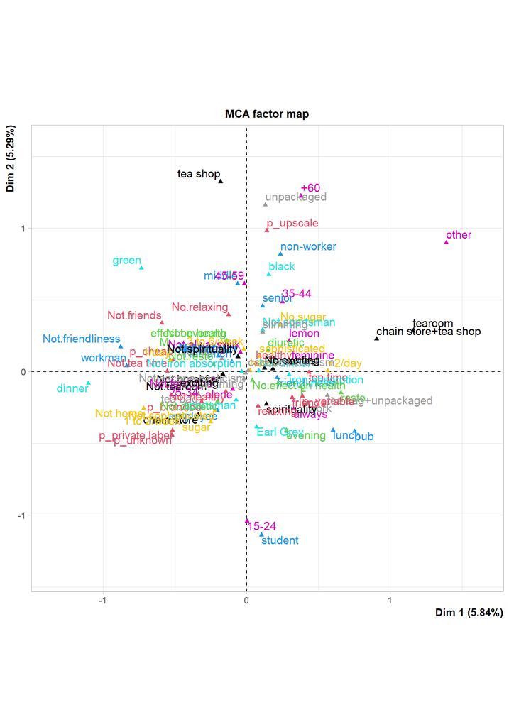

```r
plot(mca, invisible=c("ind"), habillage = "quali")
```

Multiple correspondence analysis with all variables looks quite messy and it’s difficult to interpret. I’ll concentrate on a few selected variables instead. I’ll choose Tea, How, evening, sugar, where, and lunch. Tea tells whether a person drinks Earl Grey, black tea, or green tea. How describes whether tea is drunk alone or with lemon, milk, or other. Evening describes whether tea is enjoyed in the evening or not and sugar whether a person drinks tea with or without sugar. Where includes information on whether tea is bought from a chain store, tea shop, or from both chain store and tea shop. Lunch describes whether or not tea is enjoyed at lunch.

```r
keep_columns <- c("Tea", "How", "evening", "sugar", "where", "lunch")
tea_time <- dplyr::select(tea, one_of(keep_columns))
```

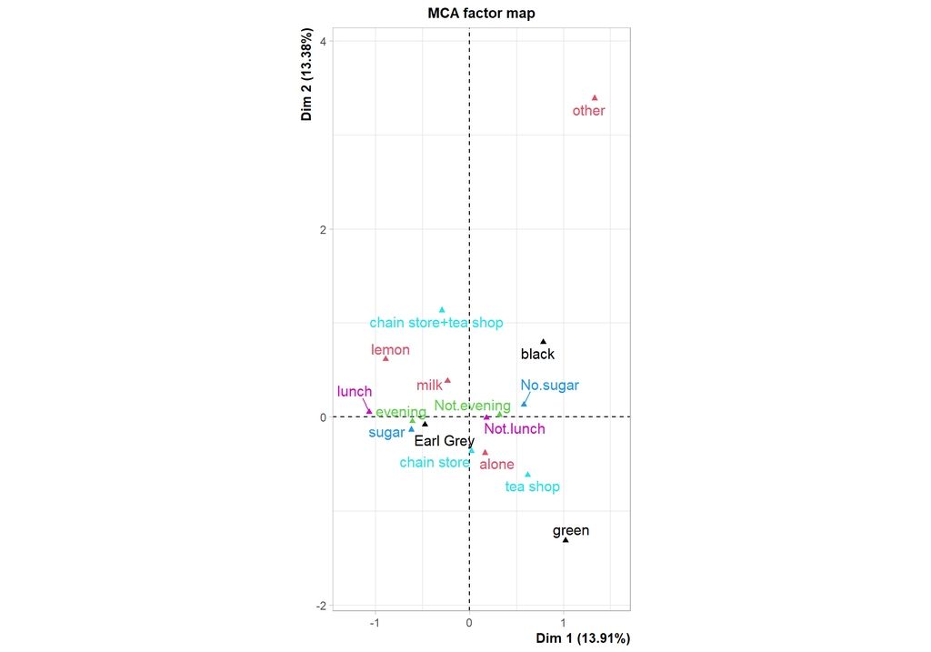

```r
mca <- MCA(tea_time, graph = FALSE)
plot(mca, invisible=c("ind"), habillage = "quali")
```

The different variables are depicted with different colours in the plot. Here we can see how different tea preferences are related to each other. The most notable thing we can see here is that furthest away from each other are the preference for green tea and to add something other than lemon or milk to the tea. The tightest cluster, on the other hand, seems to be preference for Earl Grey, sugar, and drinking tea in he evening.